# HW3_TS_KatieBaerveldt

Katie B

9/25/2019

# 7. Consider wmurders, the number of women murdered each year (per 100,000 standard population) in the United States.

*a. By studying appropriate graphs of the series in R, find an appropriate ARIMA( p,d,q ) model for these data.*

Overview of data and library setup:

```r
library(tseries)
library(forecast)
library(zoo)
library(fBasics)
```

```r
library(ggplot2)
library(moments)
library(fpp2)
library(seasonal)
library(urca)
library(stats)
library(data.table)

?wmurders
```

```
## starting httpd help server ...
```

```
##  done
```

Standard ts graphs and EDA:

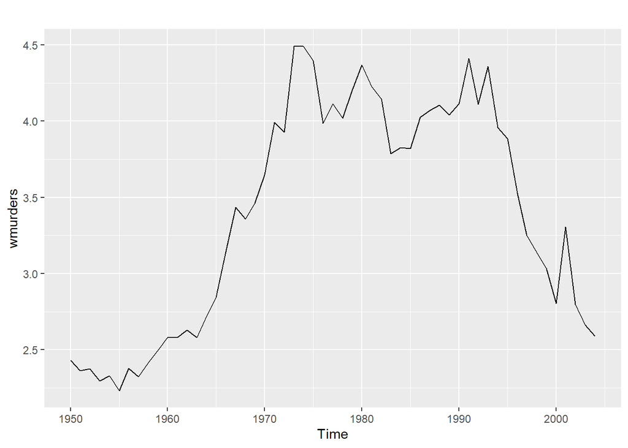

```r
autoplot(wmurders)
```

```r
basicStats(wmurders)
```

```
##               wmurders
## nobs         55.000000
## NAs           0.000000
## Minimum       2.233017
## Maximum       4.491541
## 1. Quartile   2.609338
## 3. Quartile   4.054578
## Mean          3.392687
## Median        3.462620
## Sum         186.597792
## SE Mean       0.100948
## LCL Mean      3.190299
## UCL Mean      3.595075
## Variance      0.560475
## Stdev         0.748649
## Skewness     -0.138623
## Kurtosis     -1.565502
```

If the data had stopped earlier than the mid-90s, I would have surely said that there was obvious trend, however from the basic plot alone it’s not as easily discernable. Seasonality is more difficult to pinpoint, if it exists in the data, because the data is collected annually and I suspect that the nature of murder may not operate on a seasonal basis but rather cyclical, if at all. A cyclical event, or a shock, would potentially explain the decline in female murders in the mid-70s, mid-80s and the sharp fall in the mid-90s.

I’m not convinced this is stationary by itself, so I will try some basic transformations first as we did in Class 5.

1. Log & (2) Box Cox:

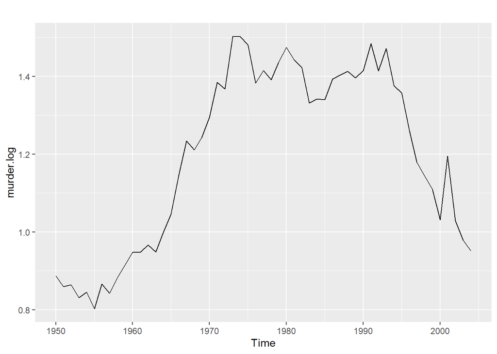

```r
murder.log <- log(wmurders)
autoplot(murder.log)
```

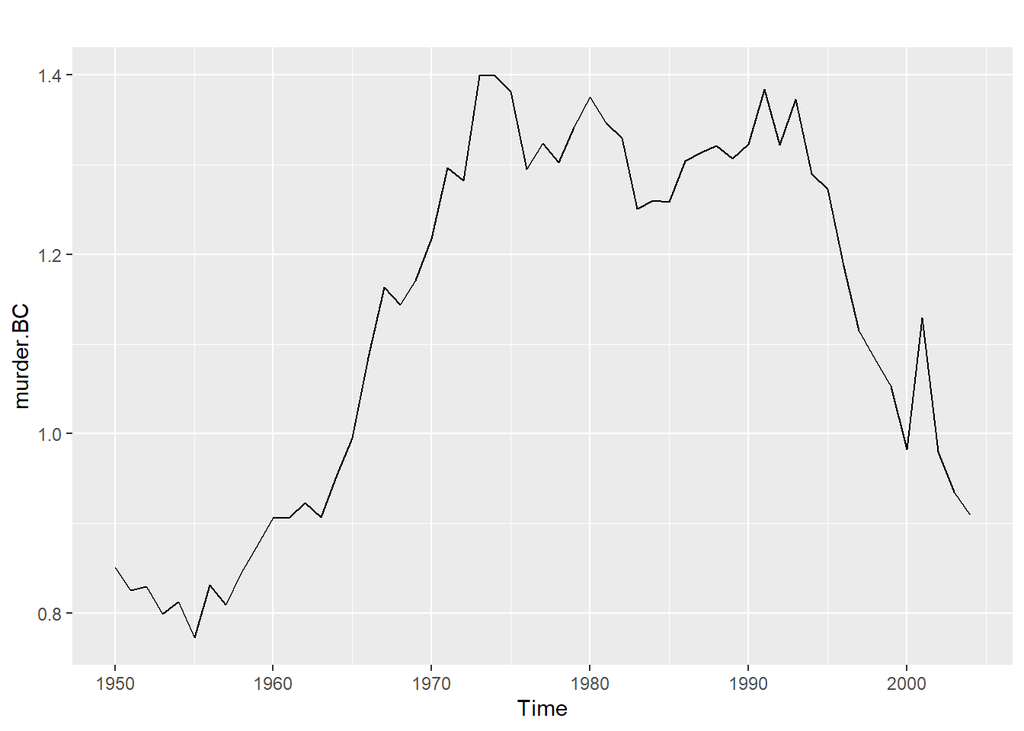

```r
murder.BC <- BoxCox(wmurders, lambda="auto")
autoplot(murder.BC)
```

Some difference but not much. Now I’ll look at the QQ plot and skewness as well as kurtosis:`

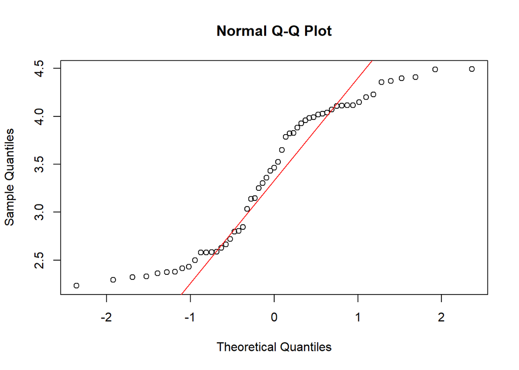

```r
qqnorm(wmurders)
qqline(wmurders, col = 2)
```

```r
skewness(wmurders)
```

```
## [1] -0.1424913
```

```r
kurtosis(wmurders)
```

```
## [1] 1.48812
```

The negative skewness suggests that my distribution is not very normal, and by looking at the tails on the QQ plot it does seem to confirm that my distribution isn’t very even. Since I’m still suspicious that my data isn’t stationary, I will now try testing different stabilization methods and testing the models.

First, I’ll try first-order differencing my ts and compare alongside the original series:

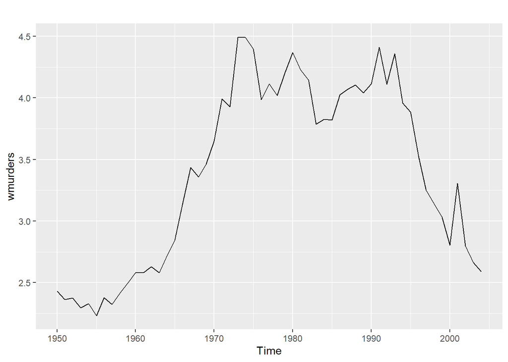

```r
autoplot(wmurders)
```

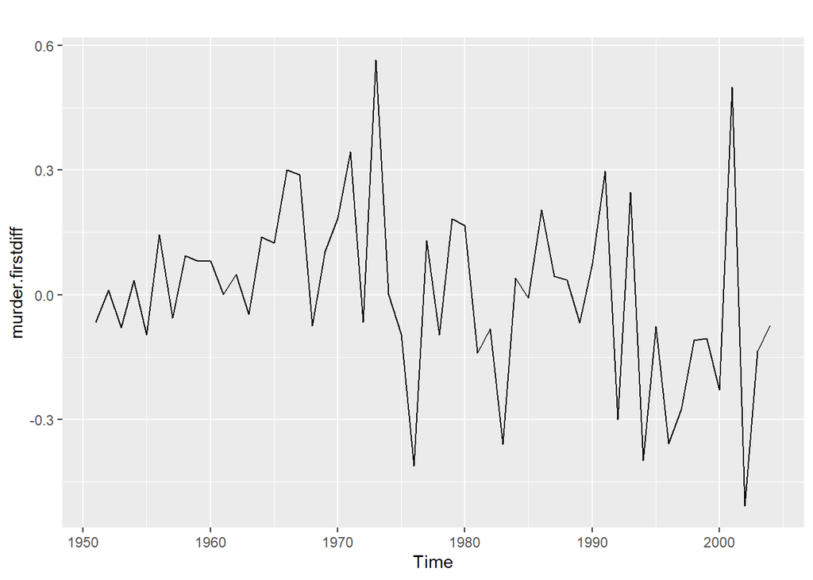

```r
murder.firstdiff <- diff(wmurders)
autoplot(murder.firstdiff)
```

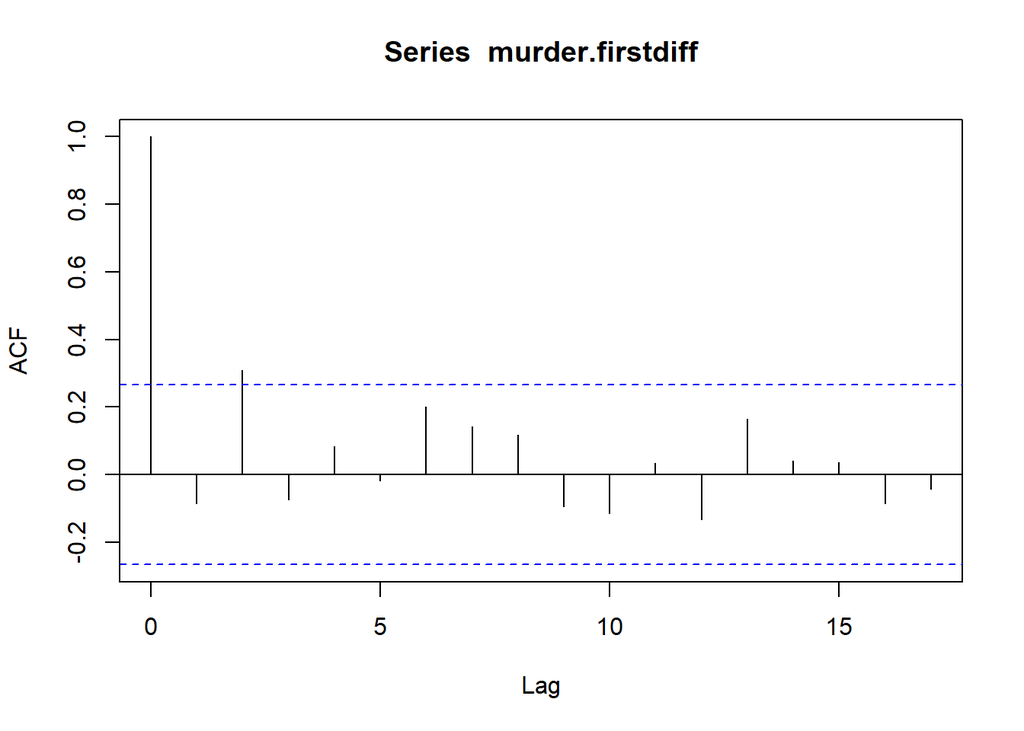

```r
acf(murder.firstdiff)
```

```r
Box.test(murder.firstdiff,lag=10,type='Ljung')
```

```
##
##  Box-Ljung test
##
## data:  murder.firstdiff
## X-squared = 12.958, df = 10, p-value = 0.226
```

H0: p > 0.05; normal distribution, stationary H1: p < 0.05; irregular distribution, non-stationary

There are only two significant lags in the ACF plot and the p value is 0.226, so I don’t feel the need to perform second-order differencing. Since I have a value I feel is stationary, I’m going to perform more testing to double check if it’s good to go:

```r
summary(ur.kpss(murder.firstdiff))
```

```
##
## #######################
## # KPSS Unit Root Test #
## #######################
##
## Test is of type: mu with 3 lags.
##
## Value of test-statistic is: 0.4697
##
## Critical value for a significance level of:
##                 10pct  5pct 2.5pct  1pct
## critical values 0.347 0.463  0.574 0.739
```

This is conflicting, because my test statistic is only smaller than two of my critical values. According to my KPSS unit root test, this may not be fully stationary. Now I’ll try and see if I should go forward with second-order differencing:

```r
ndiffs(wmurders, alpha = 0.05)
```

```
## [1] 2
```

```r
ndiffs(murder.firstdiff, alpha = 0.05)
```

```
## [1] 1
```

Confirmed, I’ll do second-order differencing and run another unit test:

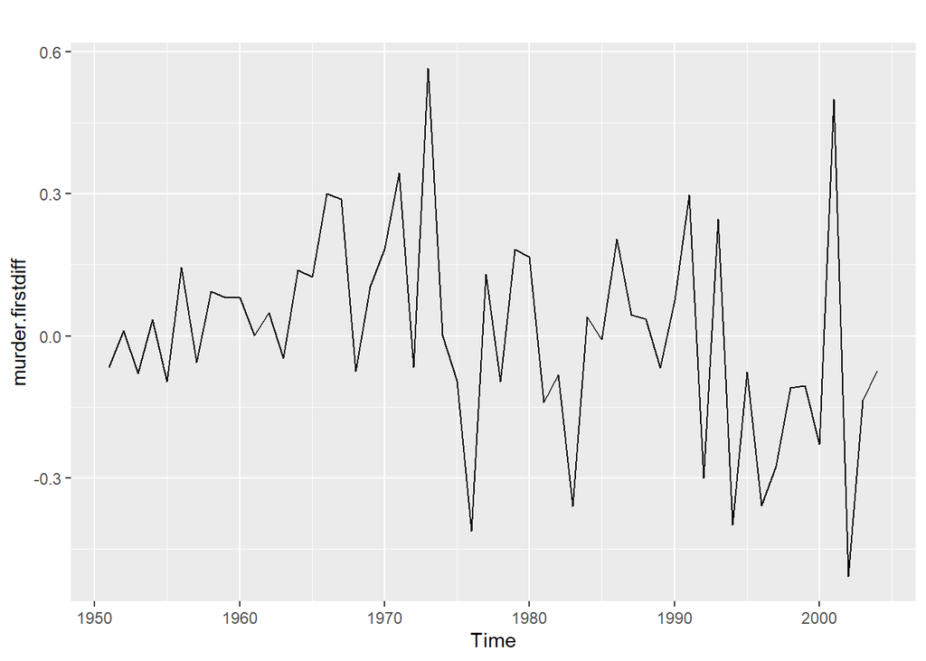

```r
murder.seconddiff <- diff(murder.firstdiff)
autoplot(murder.firstdiff)
```

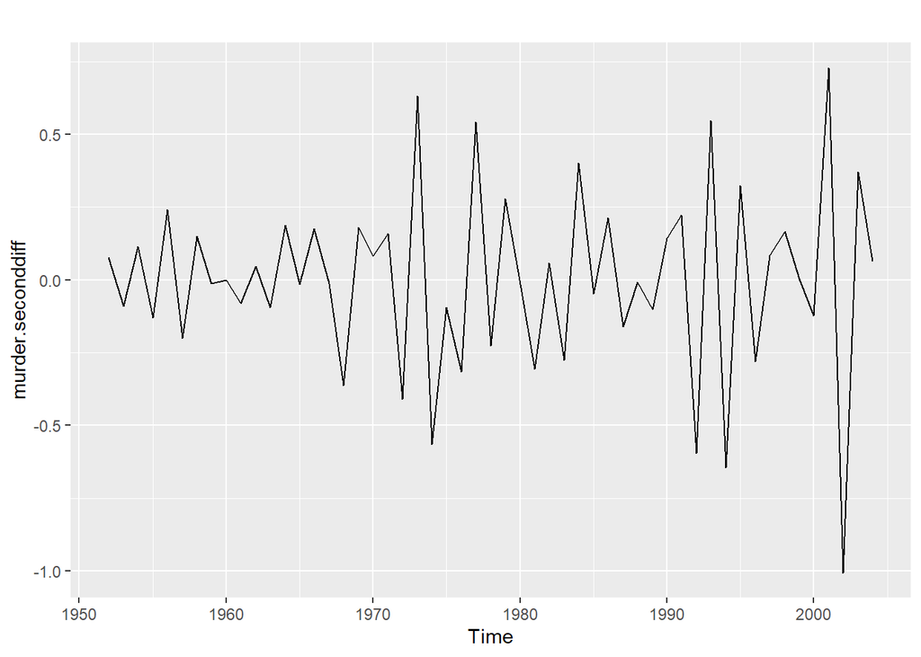

```r
autoplot(murder.seconddiff)
```

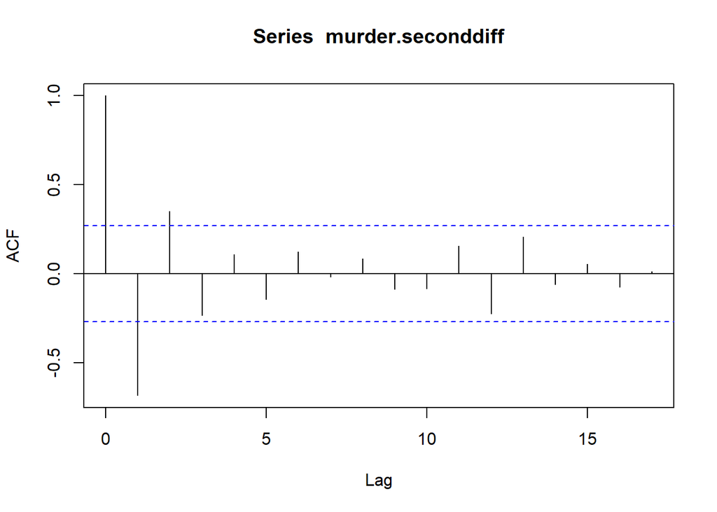

```r
acf(murder.seconddiff)
```

```r
Box.test(murder.seconddiff,lag=10,type='Ljung')
```

```
##
##  Box-Ljung test
##
## data:  murder.seconddiff
## X-squared = 40.778, df = 10, p-value = 1.235e-05
```

```r
summary(ur.kpss(murder.seconddiff))
```

```
##
## #######################
## # KPSS Unit Root Test #
## #######################
##
## Test is of type: mu with 3 lags.
##
## Value of test-statistic is: 0.0458
##
## Critical value for a significance level of:
##                 10pct  5pct 2.5pct  1pct
## critical values 0.347 0.463  0.574 0.739
```

Now, my ACF/Box test is telling me to reject the null hypothesis, but my unit root test is telling me that I should move forward with the second order difference. Because the data series looks more stationary with the second order rather than first, I will move forward with murder.seconddiff.

Before I can determine how I want to form my ARIMA model, I still need to determine my AR and MA factors. I’ll start with AR:

```r
library(stats) # code would not run unless I reinstated the stats package here
murder.lag <- lag(murder.seconddiff, k=1)
head(wmurders, 12)
```

```
## Time Series:
## Start = 1950
## End = 1961
## Frequency = 1
##  [1] 2.429415 2.363364 2.374305 2.295520 2.329716 2.233017 2.378179
##  [8] 2.322671 2.416556 2.498199 2.579453 2.580840
```

```r
head(murder.lag,12)
```

```
## Time Series:
## Start = 1951
## End = 1962
## Frequency = 1
##  [1]  0.076992 -0.089726  0.112981 -0.130895  0.241861 -0.200670  0.149393
##  [8] -0.012242 -0.000389 -0.079867  0.047066 -0.095893
```

```r
murder_AR <- lm(murder.seconddiff~murder.lag)
summary(murder_AR)
```

```
##
## Call:
## lm(formula = murder.seconddiff ~ murder.lag)
##
## Residuals:
##        Min         1Q     Median         3Q        Max
## -1.082e-16 -1.858e-17 -1.211e-17 -6.890e-18  8.143e-16
##
## Coefficients:
##               Estimate Std. Error   t value Pr(>|t|)
## (Intercept) -4.468e-20  1.619e-17 -3.00e-03    0.998
## murder.lag   1.000e+00  5.101e-17  1.96e+16   <2e-16 ***
## ---
## Signif. codes:  0 '***' 0.001 '**' 0.01 '*' 0.05 '.' 0.1 ' ' 1
##
## Residual standard error: 1.179e-16 on 51 degrees of freedom
## Multiple R-squared:      1,  Adjusted R-squared:      1
## F-statistic: 3.843e+32 on 1 and 51 DF,  p-value: < 2.2e-16
```

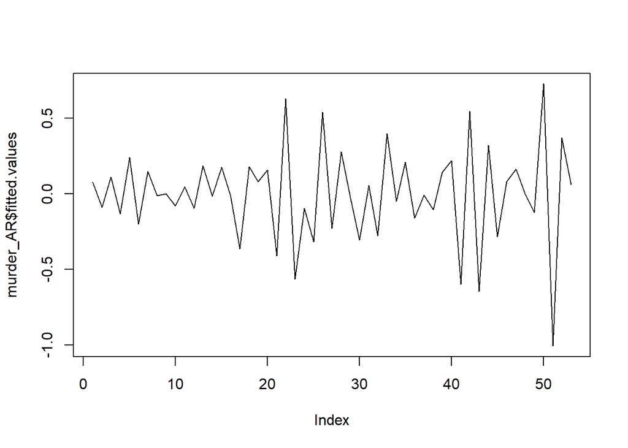

```r
plot(murder_AR$fitted.values, type="l")
```

Moving Avg component:

```r
forecast.errors <- murder_AR$residuals

murder.MA <- lm(murder.seconddiff~forecast.errors)
summary(murder.MA)
```

```
##
## Call:
## lm(formula = murder.seconddiff ~ forecast.errors)
##
## Residuals:
##      Min       1Q   Median       3Q      Max
## -1.00607 -0.13077 -0.00026  0.17638  0.72878
##
## Coefficients:
##                   Estimate Std. Error t value Pr(>|t|)
## (Intercept)     -1.282e-04  4.444e-02  -0.003    0.998
## forecast.errors  1.236e+00  3.844e+14   0.000    1.000
##
## Residual standard error: 0.3236 on 51 degrees of freedom
## Multiple R-squared:  1.88e-31,   Adjusted R-squared:  -0.01961
## F-statistic: 9.59e-30 on 1 and 51 DF,  p-value: 1
```

```r
#plotting doesn't work here since this is lm and not ts
```

Forming the ARIMA model:

p = number of lagged observations used in the autoregressive model  
d = number of differences performed to make a time series stationary  
q = number of lagged forecast errors used in a moving average model (determine from acf lags that are significant)

Based on what I’ve done so far, I will make my initial ARIMA model with p = 1, d = 2, and q = 0

*b. Should you include a constant in the model? Explain.*

Interpreting this as “should I keep one of my ARIMA variables the same throughout testing?”, I would assert that it depends on your data and the degree of work already done on the model. If I was certain that my p,d, or q value was to be kept strictly at a specific value, I would argue yes. However, given the nature of testing a manual ARIMA model and in this case, I would say no to always having a constant value because this is a black box model and I want to perform as much manipulation as possible. If anything, I would test my d variable through modeling and with the ndiffs functions first since you would typically not move past second order differencing. Then, I would keep that as my constant.

*c. Write this model in terms of the backshift operator.*

(1−ϕ1B−⋯−ϕB)(1−B)2yt = c+(1+θ1B+⋯+θ0)εt

*d. Fit the model using R and examine the residuals. Is the model satisfactory?*

```r
fit <- Arima(wmurders, order=c(1,2,0))
fit
```

```
## Series: wmurders
## ARIMA(1,2,0)
##
## Coefficients:
##           ar1
##       -0.6719
## s.e.   0.0981
##
## sigma^2 estimated as 0.05471:  log likelihood=2
## AIC=0   AICc=0.24   BIC=3.94
```

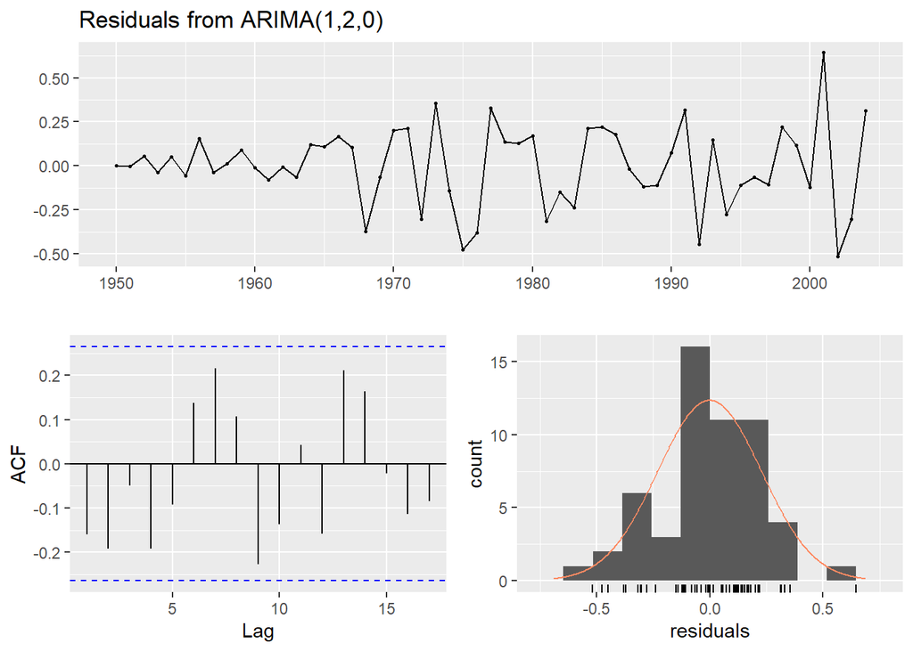

```
##
##  Ljung-Box test
##
## data:  Residuals from ARIMA(1,2,0)
## Q* = 16.452, df = 9, p-value = 0.05802
##
## Model df: 1.   Total lags used: 10
```

```r
checkresiduals(fit)
```

It isn’t a bad model, and my AIC seems low, but I do notice my ACF plot is showing some trend and that my residual histrogram is distributing a little unevenly. The peaks and valleys between my lags could be less extreme as well, so I will play around with my ARIMA to see where I can alter the model.

```r
fit2 <- Arima(wmurders, order=c(2,2,0)) #adjusting AR by 1 lag while keeping the rest constant
fit2
```

```
## Series: wmurders
## ARIMA(2,2,0)
##
## Coefficients:
##           ar1      ar2
##       -0.8289  -0.2246
## s.e.   0.1346   0.1353
##
## sigma^2 estimated as 0.05292:  log likelihood=3.34
## AIC=-0.68   AICc=-0.19   BIC=5.23
```

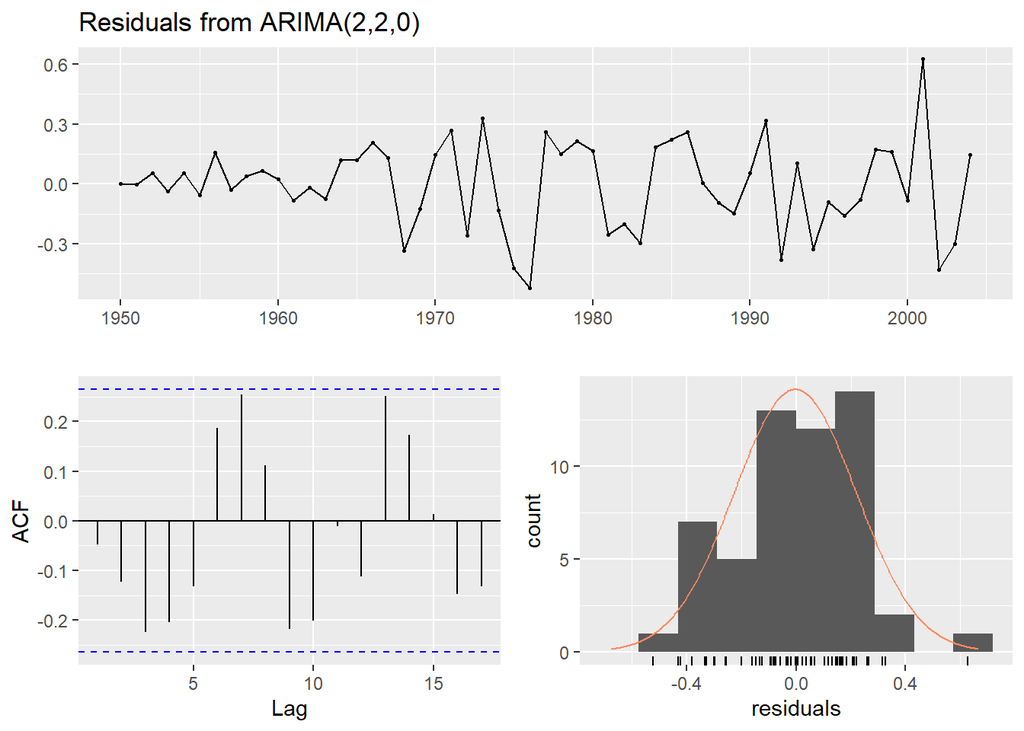

```
##
##  Ljung-Box test
##
## data:  Residuals from ARIMA(2,2,0)
## Q* = 21.05, df = 8, p-value = 0.007015
##
## Model df: 2.   Total lags used: 10
```

```r
checkresiduals(fit2)
```

```r
fit3 <- Arima(wmurders, order=c(1,1,0)) #only first-order differencing
fit3
```

```
## Series: wmurders
## ARIMA(1,1,0)
##
## Coefficients:
##           ar1
##       -0.0841
## s.e.   0.1346
##
## sigma^2 estimated as 0.04616:  log likelihood=6.92
## AIC=-9.85   AICc=-9.61   BIC=-5.87
```

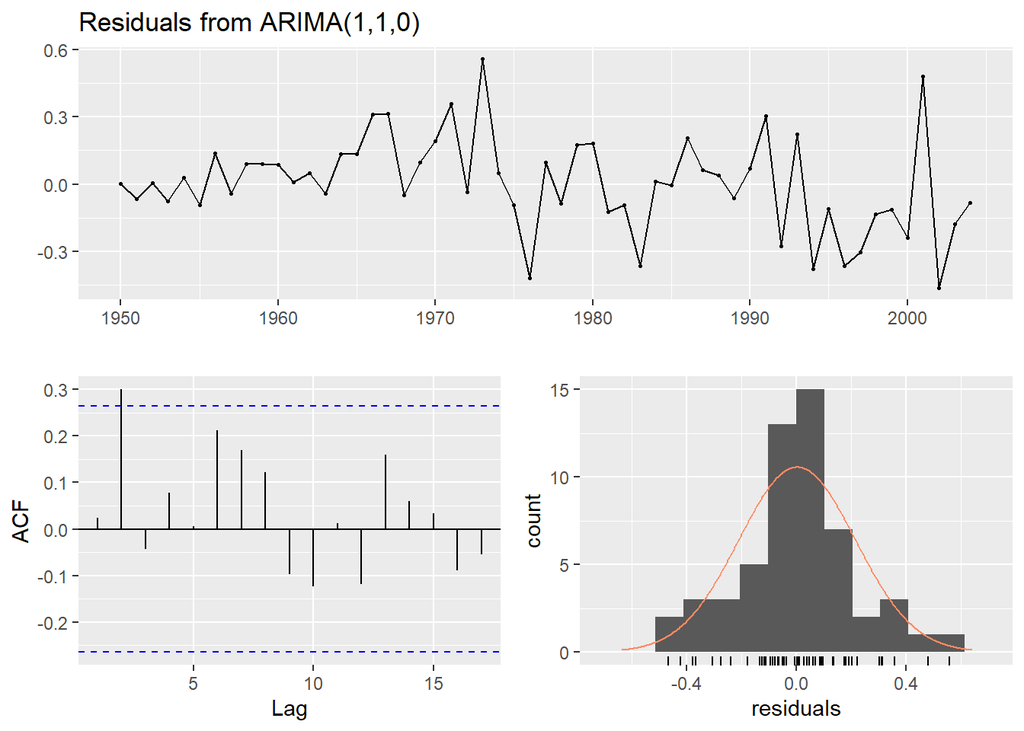

```
##
##  Ljung-Box test
##
## data:  Residuals from ARIMA(1,1,0)
## Q* = 13.281, df = 9, p-value = 0.1503
##
## Model df: 1.   Total lags used: 10
```

```r
checkresiduals(fit3)
```

```r
fit4 <- Arima(wmurders, order=c(1,2,1)) #adding the MA component
fit4
```

```
## Series: wmurders
## ARIMA(1,2,1)
##
## Coefficients:
##           ar1      ma1
##       -0.2434  -0.8261
## s.e.   0.1553   0.1143
##
## sigma^2 estimated as 0.04632:  log likelihood=6.44
## AIC=-6.88   AICc=-6.39   BIC=-0.97
```

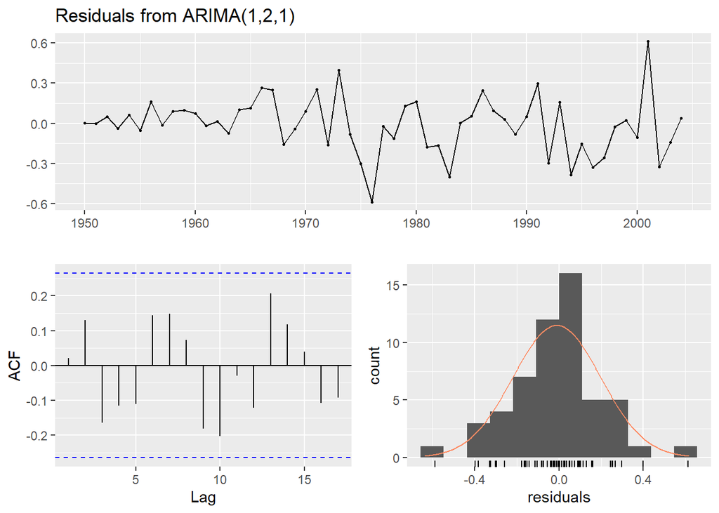

```
##
##  Ljung-Box test
##
## data:  Residuals from ARIMA(1,2,1)
## Q* = 12.419, df = 8, p-value = 0.1335
##
## Model df: 2.   Total lags used: 10
```

```r
checkresiduals(fit4)
```

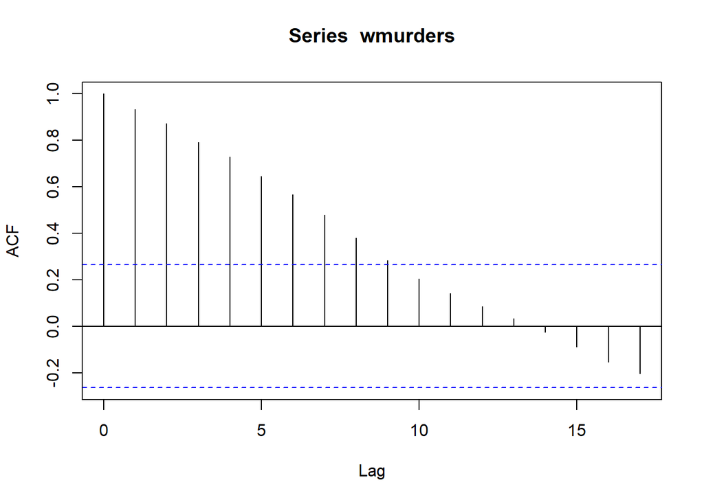

```r
acf(wmurders )
```

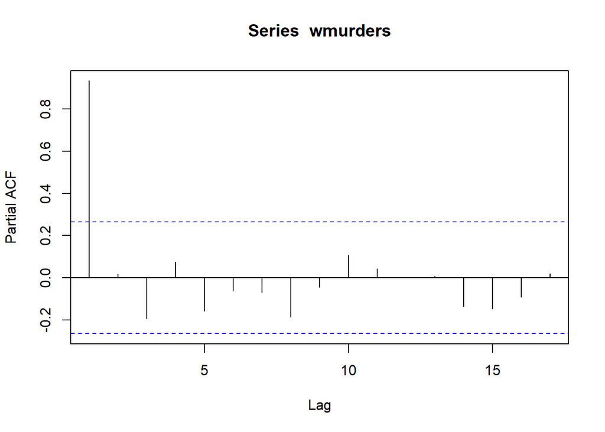

```r
pacf(wmurders )
```

```r
fit5 <- Arima(wmurders, order=c(1,2,9)) #adjusting based on results from acf and pacf
fit5
```

```
## Series: wmurders
## ARIMA(1,2,9)
##
## Coefficients:
##          ar1      ma1     ma2      ma3      ma4      ma5     ma6      ma7
##       0.1713  -1.3518  0.8453  -0.4801  -0.0177  -0.0304  0.5519  -0.2791
## s.e.  0.3908   0.4386  0.5814   0.3435   0.2709   0.2856  0.3675   0.4778
##          ma8      ma9
##       0.1283  -0.3666
## s.e.  0.3792   0.2417
##
## sigma^2 estimated as 0.03641:  log likelihood=12.44
## AIC=-2.89   AICc=3.55   BIC=18.78
```

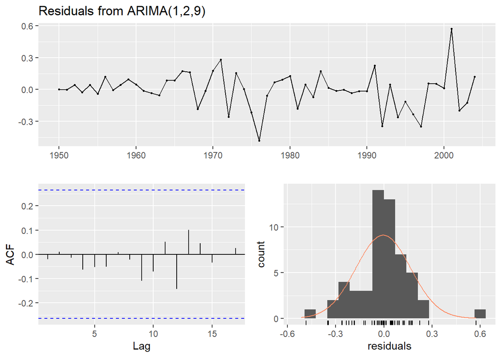

```
##
##  Ljung-Box test
##
## data:  Residuals from ARIMA(1,2,9)
## Q* = 4.2734, df = 3, p-value = 0.2334
##
## Model df: 10.   Total lags used: 13
```

```r
checkresiduals(fit5)
```

*e.&f. Forecast three times ahead*

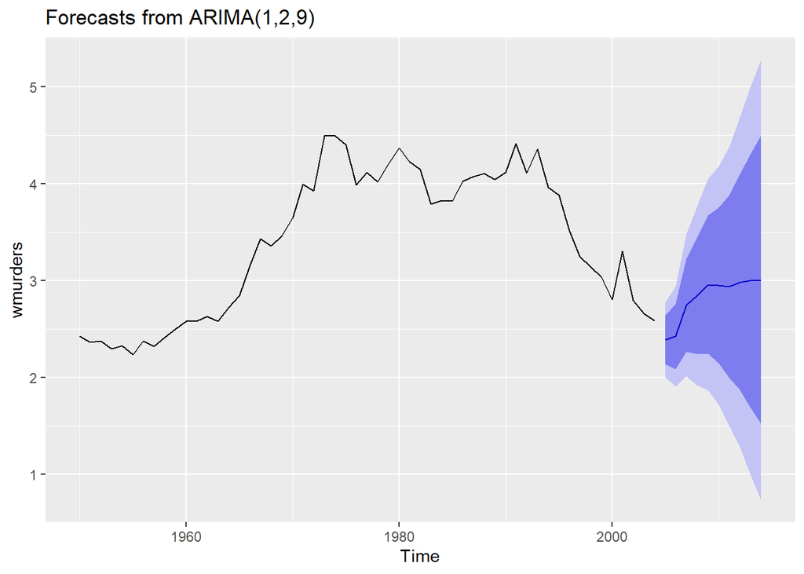

```r
autoplot(forecast(fit5), h=36)
```

*g. Does auto.arima() give the same model you have chosen? If not, which model do you think is better?*

```r
library(tidyverse)
library(xts)
fit.auto <- auto.arima(wmurders, seasonal=FALSE)

fit.auto
```

```
## Series: wmurders
## ARIMA(1,2,1)
##
## Coefficients:
##           ar1      ma1
##       -0.2434  -0.8261
## s.e.   0.1553   0.1143
##
## sigma^2 estimated as 0.04632:  log likelihood=6.44
## AIC=-6.88   AICc=-6.39   BIC=-0.97
```

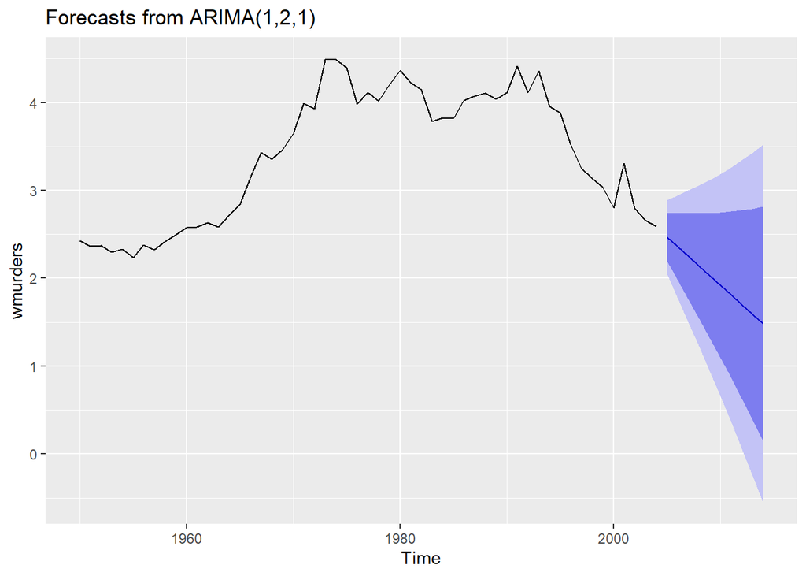

```r
autoplot(forecast(fit.auto), h=36)
```

The auto.arima() chose the model that I almost chose, with a MA component (1,2,1), which correlates with my previous ACF/PACF results. The AICC of of my original model is closer to 0 than this one, so I would be more comfortable using the original (1,2,9).

# 9. For the usgdp series:

*a. If necessary, find a suitable Box-Cox transformation for the data;*

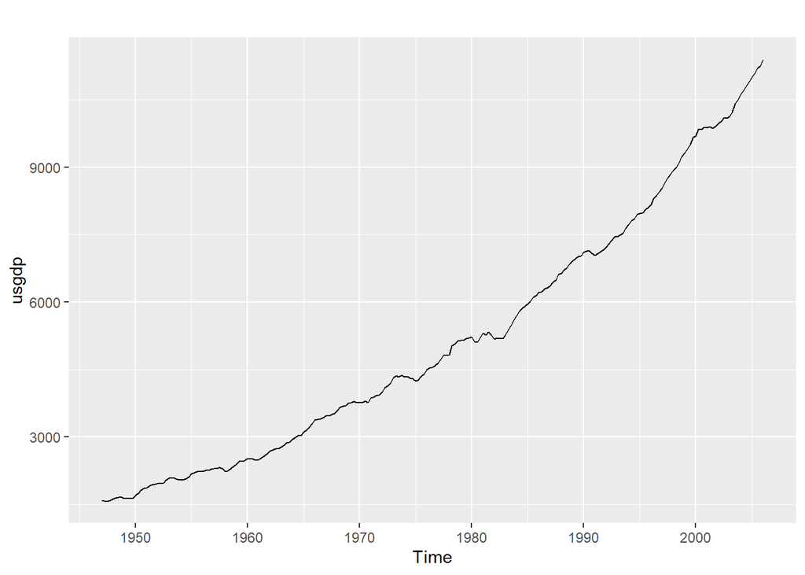

```r
?usgdp

autoplot(usgdp)
```

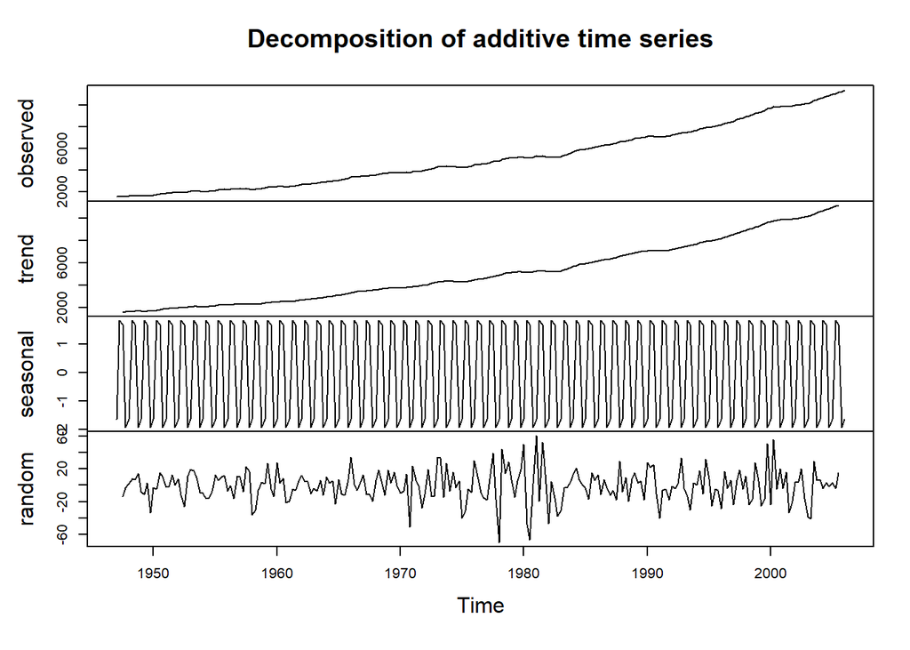

```r
plot(decompose(usgdp)) #additive
```

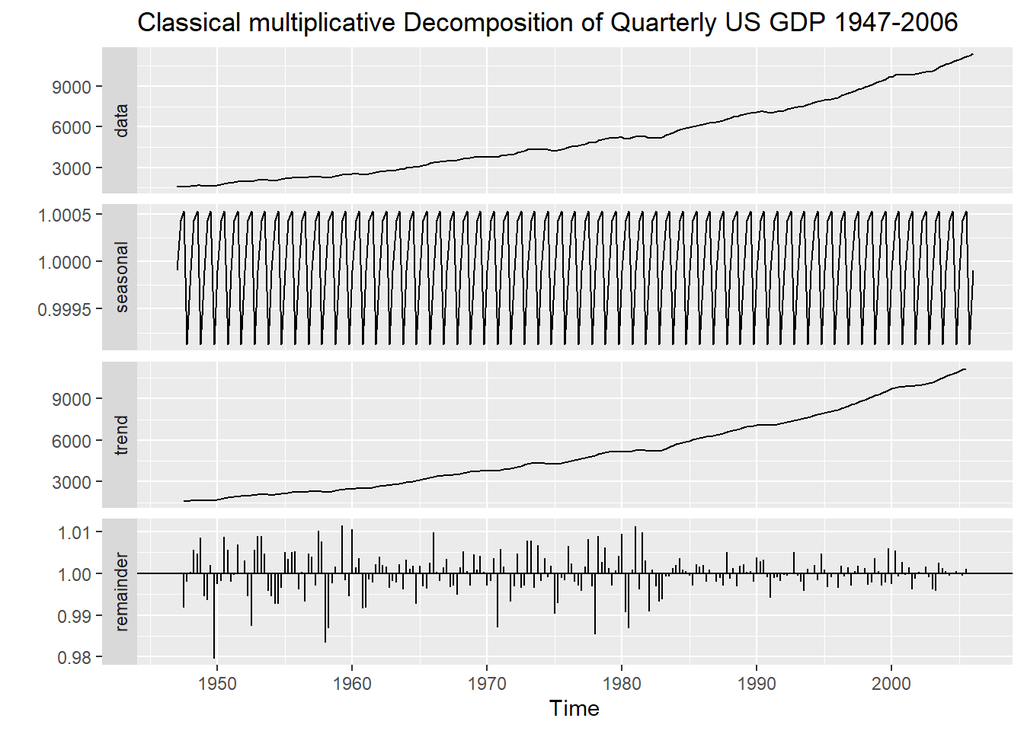

```r
usgdp %>% decompose(type="multiplicative") %>%
  autoplot() + xlab("Time") +
  ggtitle("Classical multiplicative Decomposition of Quarterly US GDP 1947-2006")
```

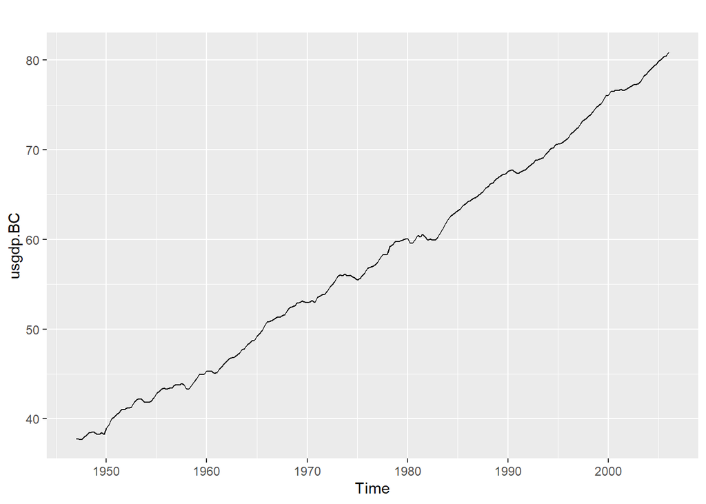

```r
usgdp.BC <- BoxCox(usgdp, lambda="auto")
autoplot(usgdp.BC)
```

The BC transformation does not get rid of overall trend or seasonality, but it did seem to diminish the exponential component of the data. I’ve chosen to use this instead of the original ts data moving forward:

*b. Fit a suitable ARIMA model to the transformed data using auto.arima()*

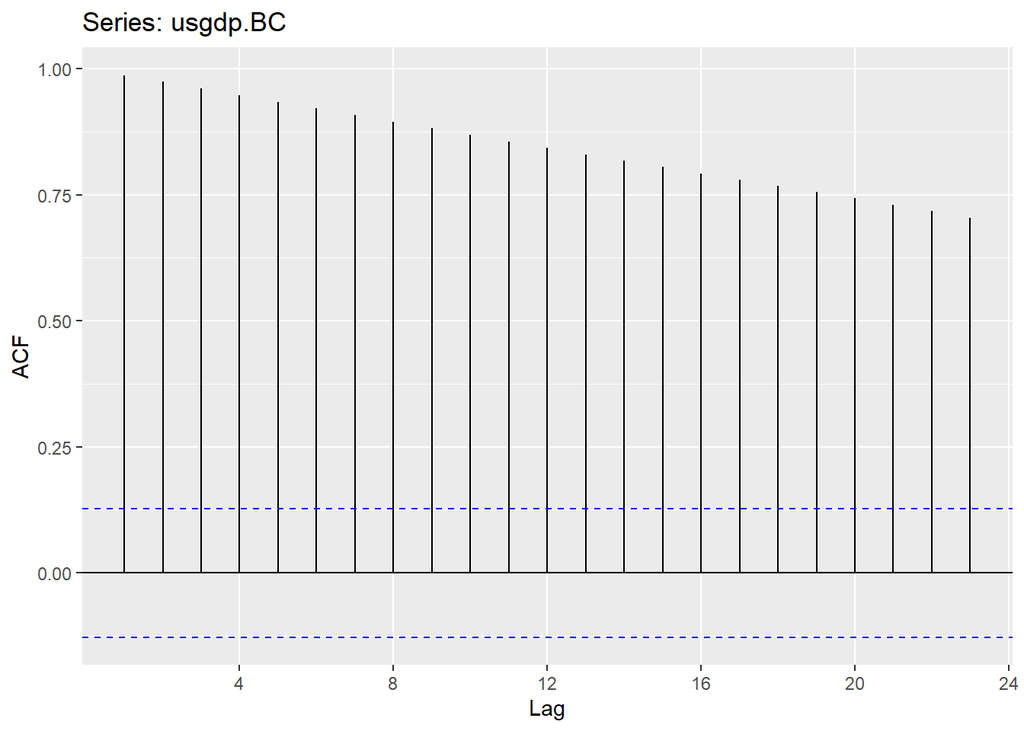

```r
ggAcf(usgdp.BC)
```

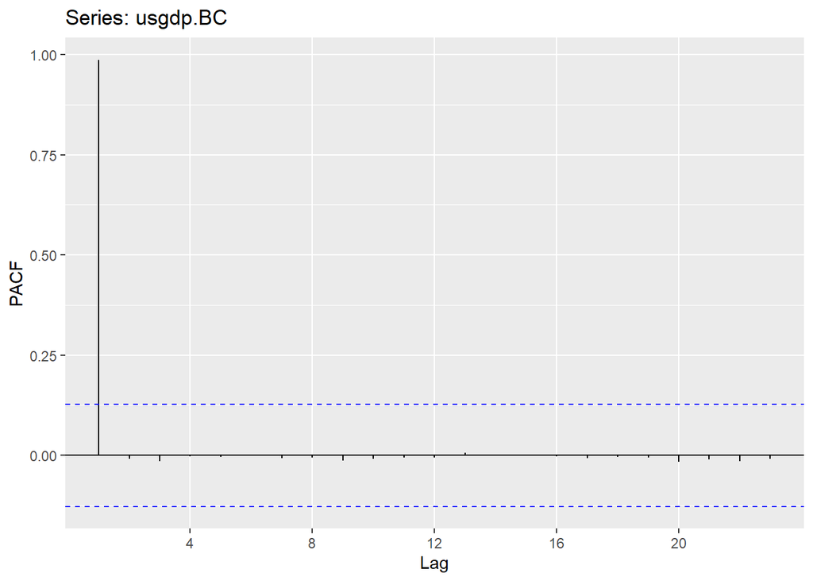

```r
ggPacf(usgdp.BC)
```

```r
ndiffs(usgdp.BC, alpha = 0.05)
```

```
## [1] 1
```

```r
fit0.usgdp <- auto.arima(usgdp.BC, seasonal=TRUE)

fit0.usgdp
```

```
## Series: usgdp.BC
## ARIMA(2,1,0) with drift
##
## Coefficients:
##          ar1     ar2   drift
##       0.2795  0.1208  0.1829
## s.e.  0.0647  0.0648  0.0202
##
## sigma^2 estimated as 0.03518:  log likelihood=61.56
## AIC=-115.11   AICc=-114.94   BIC=-101.26
```

It looks like auto.arima() chose (2,1,0) with drift. I’m curious where it determined the AR lags to use and why it didn’t use anything for MA, but since it’s a black box model I have no definitive way of knowing.

*c. Try some other plausible models by experimenting with the orders chosen*

Seasonal ARIMA fit testing:

```r
fit1.usgdp <- Arima(usgdp.BC, order=c(3,1,0), seasonal=c(3,1,0)) #AR focused
fit2.usgdp <- Arima(usgdp.BC, order=c(0,1,1), seasonal=c(0,1,1)) #MA focused
fit3.usgdp <- Arima(usgdp.BC, order=c(0,2,0), seasonal=c(0,2,0)) #Diff focused

fit1.usgdp
```

```
## Series: usgdp.BC
## ARIMA(3,1,0)(3,1,0)[4]
##
## Coefficients:
##          ar1     ar2      ar3     sar1     sar2     sar3
##       0.3399  0.1121  -0.0908  -0.6932  -0.4961  -0.3873
## s.e.  0.0662  0.0700   0.0675   0.0632   0.0689   0.0615
##
## sigma^2 estimated as 0.04488:  log likelihood=32.09
## AIC=-50.18   AICc=-49.68   BIC=-26.05
```

```r
fit2.usgdp
```

```
## Series: usgdp.BC
## ARIMA(0,1,1)(0,1,1)[4]
##
## Coefficients:
##          ma1     sma1
##       0.2418  -0.9814
## s.e.  0.0537   0.0478
##
## sigma^2 estimated as 0.03749:  log likelihood=46.42
## AIC=-86.83   AICc=-86.73   BIC=-76.49
```

```r
fit3.usgdp
```

```
## Series: usgdp.BC
## ARIMA(0,2,0)(0,2,0)[4]
##
## sigma^2 estimated as 0.3133:  log likelihood=-192.98
## AIC=387.96   AICc=387.98   BIC=391.39
```

Clearly we won’t be using second-order differencing in our ARIMA model. My AR and MA models both had an AIC closer to 0 than the auto.arima() fit. I’m curious what will happen if I combine my AR and MA elements:

```r
fit4.usgdp <- Arima(usgdp.BC, order=c(3,1,1), seasonal=c(3,1,1))
fit4.usgdp
```

```
## Series: usgdp.BC
## ARIMA(3,1,1)(3,1,1)[4]
##
## Coefficients:
##           ar1     ar2     ar3     ma1     sar1     sar2     sar3     sma1
##       -0.5233  0.4028  0.0362  0.8161  -0.1446  -0.1598  -0.2318  -0.9636
## s.e.   0.1427  0.0754  0.0820  0.1247   0.0713   0.0679   0.0681   0.0435
##
## sigma^2 estimated as 0.03441:  log likelihood=59.19
## AIC=-100.38   AICc=-99.57   BIC=-69.36
```

*d. choose what you think is the best model and check the residual diagnostics;*

Now I’ll compare my auto.arima() alongside my fit1:

```r
fit0.usgdp
```

```
## Series: usgdp.BC
## ARIMA(2,1,0) with drift
##
## Coefficients:
##          ar1     ar2   drift
##       0.2795  0.1208  0.1829
## s.e.  0.0647  0.0648  0.0202
##
## sigma^2 estimated as 0.03518:  log likelihood=61.56
## AIC=-115.11   AICc=-114.94   BIC=-101.26
```

```r
fit1.usgdp
```

```
## Series: usgdp.BC
## ARIMA(3,1,0)(3,1,0)[4]
##
## Coefficients:
##          ar1     ar2      ar3     sar1     sar2     sar3
##       0.3399  0.1121  -0.0908  -0.6932  -0.4961  -0.3873
## s.e.  0.0662  0.0700   0.0675   0.0632   0.0689   0.0615
##
## sigma^2 estimated as 0.04488:  log likelihood=32.09
## AIC=-50.18   AICc=-49.68   BIC=-26.05
```

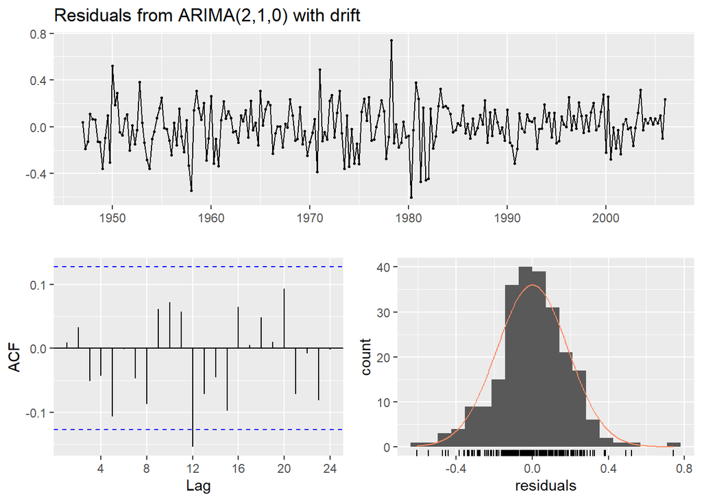

```
##
##  Ljung-Box test
##
## data:  Residuals from ARIMA(2,1,0) with drift
## Q* = 6.5772, df = 5, p-value = 0.254
##
## Model df: 3.   Total lags used: 8
```

```r
checkresiduals(fit0.usgdp)
```

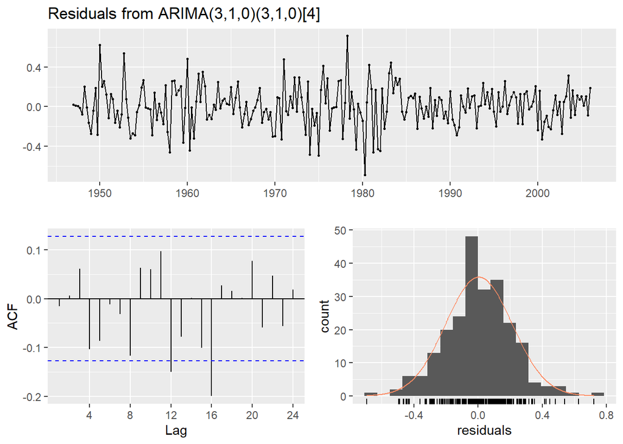

```
##
##  Ljung-Box test
##
## data:  Residuals from ARIMA(3,1,0)(3,1,0)[4]
## Q* = 10.051, df = 3, p-value = 0.01814
##
## Model df: 6.   Total lags used: 9
```

```r
checkresiduals(fit1.usgdp)
```

*e. Produce forecasts of your fitted model. Do the forecasts look reasonable?*

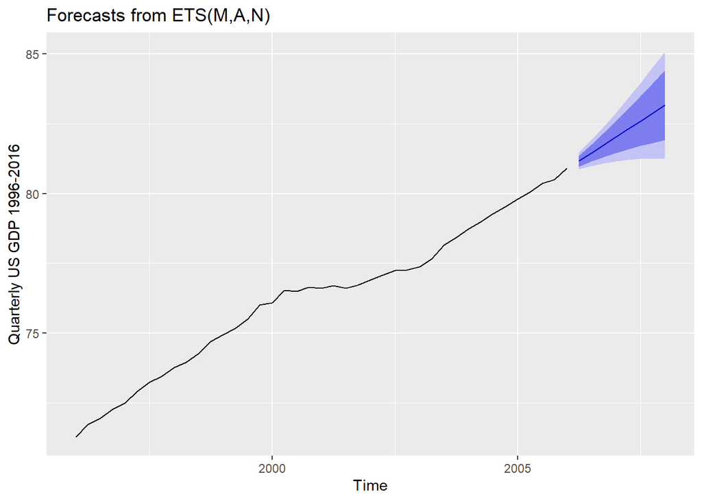

```r
usgdp_data <- window(usgdp.BC, start = 1996)
fit1.usgdp <- Arima(usgdp.BC, order=c(3,1,0), seasonal=c(3,1,0))
autoplot(forecast(usgdp_data), h=40, ylab = "Quarterly US GDP 1996-2016") #next 10 years
```

*f. Compare the results with what you would obtain using ets() (with no transformation).*

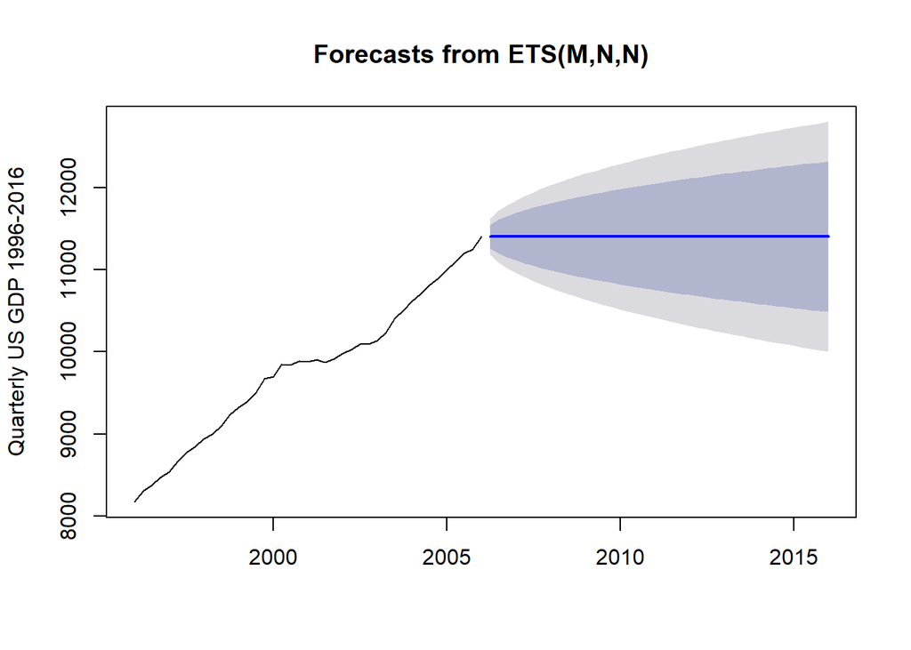

```r
usgdp_data_notrans <- window(usgdp, start = 1996)
fit_mult_usgdp <- ets(usgdp_data_notrans, model = "MNN")
plot(forecast(fit_mult_usgdp, h=40), ylab="Quarterly US GDP 1996-2016")
```

```r
summary(fit_mult_usgdp)
```

```
## ETS(M,N,N)
##
## Call:
##  ets(y = usgdp_data_notrans, model = "MNN")
##
##   Smoothing parameters:
##     alpha = 0.9999
##
##   Initial states:
##     l = 8168.2899
##
##   sigma:  0.0099
##
##      AIC     AICc      BIC
## 530.3938 531.0425 535.5345
##
## Training set error measures:
##                    ME     RMSE      MAE      MPE      MAPE      MASE
## Training set 78.91752 92.94932 81.75541 0.809311 0.8380772 0.2601481
##                    ACF1
## Training set 0.08369611
```